# Analisi degli streaming su Spotify nel 2024

# Perchè ho deciso di svolgere il progetto su questo argomento?

• l'interesse per la musica  
• il desiderio di capire quali sono i trend musicali negli altri paesi  
• un'analisi di questo tipo può essere utile per marketing e sponsorizzazione

# Quali domande mi sono posta?

1. Quali sono gli artisti che hanno il maggior numero di streaming?
2. Quali sono i paesi che hanno un maggior/minor numero di streaming?
3. Come varia la distribuzione del numero di stream nei vari paesi?
4. Qual è l'artista più ascoltato in ogni paese?

# Descrizione del Dataset

**fonte**: Kaggle  
**contenuto**: trend di streaming su Spotify nel 2024 in 20 diversi paesi del mondo  
*ad esempio*: paesi, artisti, genere, numero di stream (totali, media mensile, ultimi 30 giorni), ...

# Analisi dei dati

```python
import pandas as pd
import matplotlib as mpl
import numpy as np
import seaborn as sb
import matplotlib.pyplot as plt
import plotly.express as px   # per le mappe coropletiche

df = pd.read_csv('Desktop/moststream.csv') # importo il dataset
df.to_csv('dataset_completo4.csv', index=False)
```

# 1. Quali sono gli artisti che hanno il maggior numero di streaming?

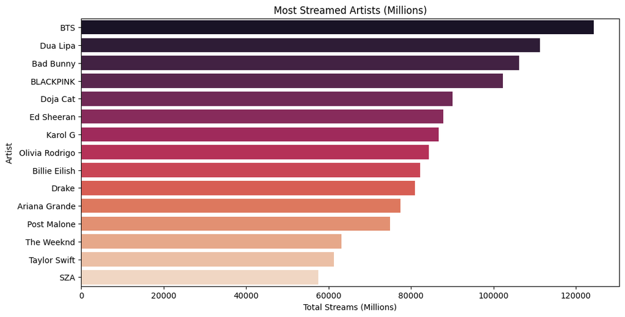

```python
# calcolo il numero di stream totale per ogni artista e li ordino in modo decrescente
top_artists = df.groupby('Artist')['Total Streams (Millions)'].sum().sort_values(ascending=False)

# imposto la grandezza del grafico
plt.figure(figsize=(12, 6))

# creo il grafico
sb.barplot(x=top_artists.values, y=top_artists.index, hue=top_artists.index, palette='rocket')

# etichetto gli assi
plt.title('Most Streamed Artists (Millions)')
plt.xlabel('Total Streams (Millions)')
plt.ylabel('Artist')

plt.show()
```

# 2. Quali sono i paesi che hanno un maggior/minor numero di streaming?

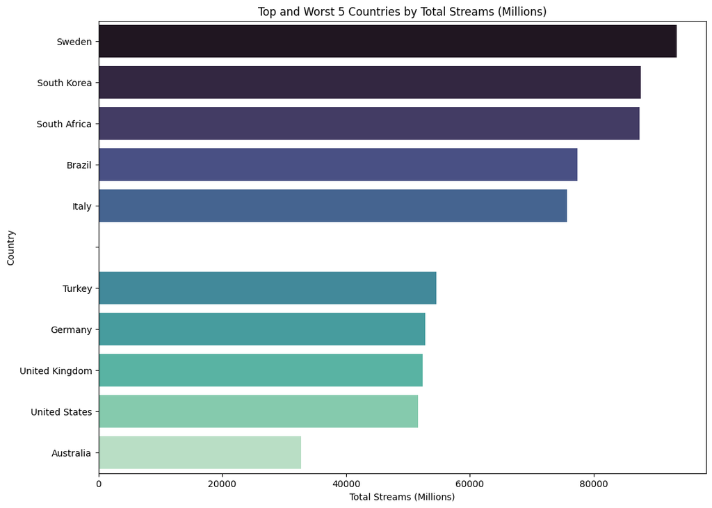

```python
# calcolo top e worst 5 paesi
top_countries = df.groupby('Country')['Total Streams (Millions)'].sum().sort_values(ascending=False).head(5)
worst_countries = df.groupby('Country')['Total Streams (Millions)'].sum().sort_values(ascending=False).tail(5)

# converto in DataFrame, resetto l'indice attuale e metto come indice numeri incrementali partendo da 0
top_df = top_countries.reset_index()
worst_df = worst_countries.reset_index()

# aggiungo una riga vuota per separare i top dai worst
separator = pd.DataFrame({'Country': [''], 'Total Streams (Millions)': [0]})

# combino assieme i due
combined_df = pd.concat([top_df, separator, worst_df])

# imposto grandezza del grafico
plt.figure(figsize=(12, 9))

# creo il grafico
sb.barplot(data=combined_df, x='Total Streams (Millions)', y='Country', hue = 'Country', palette='mako')

# etichetto gli assi
plt.title('Top and Worst 5 Countries by Total Streams (Millions)')
plt.xlabel('Total Streams (Millions)')
plt.ylabel('Country')

plt.show()
```

```python
import plotly.io as pxio
pxio.renderers.default = 'iframe_connected'

# calcolo il totale di stream per ogni paese
selezione_col_million_stream = df.groupby('Country')['Total Streams (Millions)'].sum().reset_index()

# creo una mappa coropletica
fig = px.choropleth(
    selezione_col_million_stream,
    locations = 'Country',               # nomi dei paesi per trovare la posizione sulla mappa
    locationmode = 'country names',      # specifico il tipo di dato (nomi completi dei paesi)
    color = 'Total Streams (Millions)',  # valore da mappare
    color_continuous_scale = 'Viridis',  # palette per dati non categorici (valori non discreti ma continui)
    title = 'Total Streams by Country'   # etichetta/titolo del grafico
)

fig.show(renderer='iframe')
```

[interactive chart not shown]

# 3. Come varia la distribuzione del numero di stream nei vari paesi?

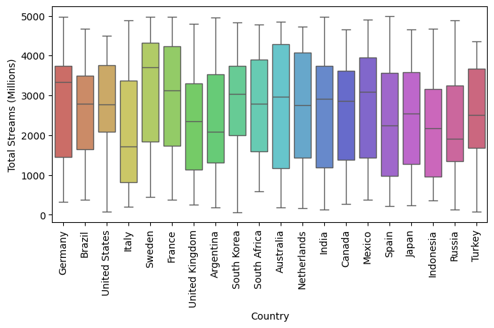

```python
# imposto la grandezza del grafico
fig, ax = plt.subplots(figsize = (8, 4))

# creo il boxplot
sb.boxplot(df, y = 'Total Streams (Millions)', x='Country', hue = 'Country', palette = 'hls' );

# ruoto le etichette
plt.xticks(rotation=90)

plt.show()
```

# 4. Qual è l'artista più ascoltato in ogni paese?

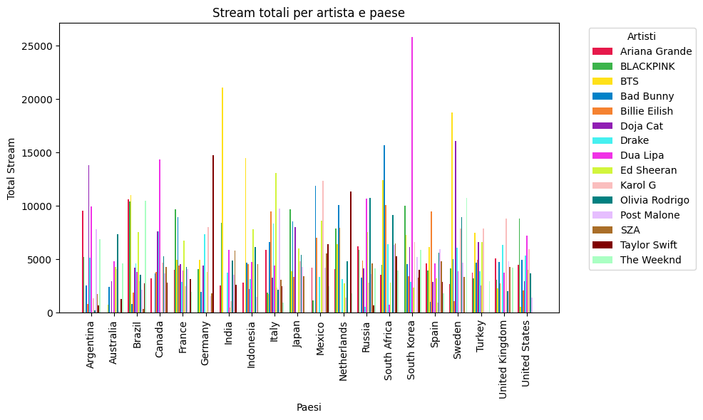

```python
# raggruppo i dati per paese e artista sommando gli stream di ogni artista per ogni paese
selezione_col_paese_artista = df.groupby(['Country', 'Artist'])['Total Streams (Millions)'].sum().unstack(fill_value=0)
#fill_value=0 per mettere 0 su valori NaN eventuali

# seleziono da dove prendere i dati che mi interessano
paesi = selezione_col_paese_artista.index
artisti = selezione_col_paese_artista.columns
valori = selezione_col_paese_artista.values

# grandezza delle barre
x = np.arange(len(paesi))       # array con posizione per ogni paese sull'asse x
larghezza = 0.8 / len(artisti)  # larghezza delle barre, divisione spazio per non sovrapporle

# creo il grafico
fig, ax = plt.subplots(figsize=(10, 6))

# creo la palette
palette = [
    '#e6194b',  # rosso
    '#3cb44b',  # verde
    '#ffe119',  # giallo
    '#0082c8',  # blu
    '#f58231',  # arancione
    '#911eb4',  # viola
    '#46f0f0',  # azzurro
    '#f032e6',  # magenta
    '#d2f53c',  # lime
    '#fabebe',  # rosa chiaro
    '#008080',  # verde petrolio
    '#e6beff',  # lilla
    '#aa6e28',  # marrone
    '#800000',  # bordeaux
    '#aaffc3'   # verde menta
]

# assegno a ogni artista un colore della palette
for i, artista in enumerate(artisti): # enumerate(artisti): per ottenere indice e nome dell'artista
    ax.bar(
           x + i * larghezza, # posizione delle barre
           valori[:, i],      # altezza delle barre
           width=larghezza,   # larghezza delle barre
           label=artista,     # do l'etichetta
           color=palette[i]   # asssegno colore dalla palette
          )

# etichetto gli assi
ax.set_xlabel('Paesi')
ax.set_ylabel('Total Stream')

# do il titolo
ax.set_title('Stream totali per artista e paese')

# centro le etichette rispetto alle barre
ax.set_xticks(x + larghezza * (len(artisti) - 1) / 2)

# ruoto le etichette
ax.set_xticklabels(paesi, rotation=90)

# porto la legenda fuori dal grafico per non coprire le barre
ax.legend(title='Artisti', bbox_to_anchor=(1.05, 1), loc='upper left')

plt.tight_layout()
plt.show()
```

```python
import plotly.io as pxio
pxio.renderers.default = 'iframe_connected'

# raggruppo per ogni paese gli stream totali per ogni artista
df_grouped = df.groupby(['Country', 'Artist'])['Total Streams (Millions)'].sum().reset_index()

# seleziono l'artista con più stream per ogni paese
top_artists_by_country = df_grouped.sort_values('Total Streams (Millions)', ascending=False)\
                                   .drop_duplicates(subset=['Country'])

# assegno a ogni artista un colore
top_artists_by_country['Top Artist'] = top_artists_by_country['Artist'].astype('category')

# creo la mappa
fig = px.choropleth(
    top_artists_by_country,
    locations = 'Country',                                   # nomi dei paesi per trovare la posizione sulla mappa
    locationmode = 'country names',                          # specifico il tipo di dato (nomi completi dei paesi)
    color = 'Top Artist',                                    # valore da mappare
    title = 'Most Streamed Artist by Country',               # etichetta/titolo del grafico
    color_discrete_sequence = px.colors.qualitative.Dark24   # palette per categorie distinte (valori discreti)
)

fig.show(renderer='iframe')
```

[interactive chart not shown]

# Conclusioni

• **Artisti con un maggior numero di stream**: BTS, Dua Lipa, Bad Bunny, BLACKPINK  
• **Paesi con un maggior numero di stream**: Svezia, Sud Corea, Sud Africa  
• **Paesi con un minor numero di stream**: Australia, Stati uniti, Regno unito  
• **Artisti più ascoltati in ogni paese**

## A quale scopo potrebbe essere utile questa analisi?

• **marketing**: i manager degli artisti possono pianificare campagne pubblicitarie o promozioni di dischi/canzoni dove gli artisti sono più popolari  
• **tour**: i manager possono organizzare concerti nei paesi dove gli artisti sono più popolari o stimare l'audience in base alla popolarità dell'artista in quel paese  
• **spotify**: può adattare i suggerimenti e le playlist in base agli artisti più popolari  
• **previsioni tendenze**: si possono predirre i trend musicali e analizzarne i cambiamenti